# 脱口秀演员热度分析和影响因素探究

## —— 基于因子分析和K-Means聚类

狗熊会

案例背景：脱口秀（TALK SHOW，中文名为英文音译）一种由观众聚集在一起讨论主持人提出的话题的广播或电视节目，是目前比较流行的一种喜剧类型。脱口秀主要发源于欧美地区，近年来脱口秀表演在国内也越来越受大众欢迎。在就业形势严峻的当下，脱口秀演员不失为一种职业选择。然而，脱口秀行业的竞争也是异常激烈。重压之下，脱口秀演员应该如何提高自己的热度？本期案例中，我们将基于因子分析和K-Means聚类的方法，探讨脱口秀演员应该如何在众多同行竞争者中脱颖而出。

这个案例的学期目标包括：

1. 学习如何在python中使用因子分析，并分析其可解释性。
2. 学习如何在Python中使用K-Means聚类，探索各类别的特点，绘制聚类中心的轮廓图。

# 准备工作

```python
import warnings
warnings.filterwarnings("ignore") # 不打印warning信息

# 导入需要的包
import pandas as pd # 用于结构化数据处理
from factor_analyzer import FactorAnalyzer  # 用于因子分析
import matplotlib.pyplot as plt  # 用于绘图
from sklearn.cluster import KMeans  # 用于Kmeans聚类
```

# 任务一：因子分析

该任务中，我们将对演员数据做因子分析。请在工作目录下找到"data_process.csv"数据，这是我们经过整合的演员各维度特征数据表，各特征维度均已经做过标准化。请读取其数据，并展示前五行。

```python
# 读取演员数据表格csv
data = pd.read_csv("data_process.csv")

# 用set_index方法将"演员"列设置为index
data.set_index("演员", inplace=True)

# 展示前5行
data.head()
```

| 演员 | 表演年限 | 出场期数 | 是否签约 | 是否组CP | 是否参加S3 | 平均表演时长 | 文稿长度 | 文稿情感得分 | 相关评论数 | 观众认可度 | 人设鲜明度 |
| --- | --- | --- | --- | --- | --- | --- | --- | --- | --- | --- | --- |
| 庞博 | 0.147324 | 1.274755 | 0.752628 | -0.636756 | 0.693889 | 1.347514 | 2.187397 | 0.827823 | 0.965754 | 0.579884 | 0.538651 |
| 周奇墨 | 0.904989 | 1.912132 | -1.279467 | -0.636756 | 0.693889 | 1.686899 | 0.788404 | -0.196404 | 1.465102 | -0.805832 | 2.282372 |
| 何广智 | -0.420925 | 1.274755 | 0.752628 | 1.512295 | 0.693889 | -0.264565 | 0.197674 | 0.502853 | 0.953305 | 0.901419 | 1.009878 |
| 徐志胜 | -0.610342 | 1.274755 | -1.279467 | 1.512295 | -1.387777 | 0.232392 | -0.033829 | 2.000783 | 0.776251 | 0.330965 | -0.070888 |
| 呼兰 | -0.042093 | 0.637377 | 0.752628 | 1.512295 | 0.693889 | -0.106993 | 0.291472 | -1.249559 | 2.447199 | -1.037754 | 0.570276 |

因子分析之前我们需要做KMO检验和Bartlett球形检验。经检验，KMO为0.54，一般适用，Bartlett球形检验的p值几乎为0，综合来看我们认为可以进行因子分析。利用手肘法，我们最终确定因子数目为5。接下来让我们取因子数为5做因子分析，得到5个因子对应的特征值，方差贡献率和方差累计贡献率。

提示：调用`FactorAnalyzer`做因子分析，参数"rotation"取"varimax"，"method"取"principal"。调用`get_factor_variance`方法获得因子分析对应的特征值、方差贡献率和方差累计贡献率。参考代码：`FactorAnalyzer(rotation='varimax', n_factors=5, method='principal')`

```python
# 因子分析
fa_5 = FactorAnalyzer(rotation='varimax', n_factors=5, method='principal')
fa_5.fit(data)

# 获得5个因子对应的特征值，方差贡献率和累计方差贡献率
fa_5_sd = fa_5.get_factor_variance()

# 用DataFrame保存并展示展示5个因子对应的特征值，方差贡献率和累计方差贡献率
fa_5_df = pd.DataFrame({'特征值': fa_5_sd[0], '方差贡献率': fa_5_sd[1], '方差累计贡献率': fa_5_sd[2]})
fa_5_df
```

|  | 特征值 | 方差贡献率 | 方差累计贡献率 |
| --- | --- | --- | --- |
| 0 | 3.047648 | 0.277059 | 0.277059 |
| 1 | 2.250297 | 0.204572 | 0.481631 |
| 2 | 1.319839 | 0.119985 | 0.601617 |
| 3 | 1.127318 | 0.102483 | 0.704100 |
| 4 | 1.205689 | 0.109608 | 0.813708 |

参考解读：可以看到因子数为5时，累计方差贡献率超过了80%。

# 任务二：因子分析可解释性

该任务中，我们将获得因子载荷矩阵，尝试分析因子可解释性并为因子命名。

提示：调用`loadings_`属性可获得因子载荷矩阵

```python
# 获得载荷矩阵并转化为DataFrame
load_mat = pd.DataFrame(fa_5.loadings_)
# 将行名换成对应的原始特征
load_mat.index = data.columns
# 展示载荷矩阵
load_mat
```

|  | 0 | 1 | 2 | 3 | 4 |
| --- | --- | --- | --- | --- | --- |
| 表演年限 | 0.009957 | 0.809545 | -0.134669 | -0.105600 | 0.000008 |
| 出场期数 | 0.795699 | -0.174269 | 0.139608 | 0.136734 | -0.031623 |
| 是否签约 | -0.143130 | 0.786807 | 0.185240 | 0.068705 | 0.322625 |
| 是否组CP | 0.152345 | 0.206082 | -0.136804 | 0.010271 | 0.908945 |
| 是否参加S3 | 0.195818 | 0.857924 | -0.193737 | -0.131217 | 0.059677 |
| 平均表演时长 | 0.848362 | 0.087552 | -0.131342 | 0.021631 | 0.026465 |
| 文稿长度 | 0.618672 | 0.348059 | -0.553499 | 0.229786 | -0.220575 |
| 文稿情感得分 | -0.000042 | -0.116825 | 0.071396 | 0.940189 | 0.011371 |
| 相关评论数 | 0.814165 | 0.038748 | 0.074856 | -0.071692 | 0.433540 |
| 观众认可度 | 0.194132 | -0.082290 | 0.882918 | 0.113496 | -0.165870 |
| 人设鲜明度 | 0.727563 | 0.127532 | 0.278911 | -0.346672 | 0.076854 |

从因子载荷矩阵中可以看出：  
“因子0”主要对应于出场期数、平均表演时长、文稿长度、相关评论数、人设鲜明度等特征，故命名为“曝光因子”  
“因子1”主要对应于表演年限、是否签约、是否参加S3（即是否参加了第三季）等特征，故命名为“经验因子”  
“因子2”主要对应于观众认可度特征，故命名为“观众认可因子”  
“因子3”主要对应于文稿情感得分特征，故命名为“文稿因子”  
“因子4”主要对应于是否组CP特征，故命名为“CP因子”  
命名后的载荷矩阵如下：

```python
# 给出最终的因子名
columns = ['曝光因子','经验因子','观众认可因子','文稿因子','CP因子']
# 将载荷矩阵列名改为因子名
load_mat.columns = columns
# 展示最终的载荷矩阵
load_mat
```

|  | 曝光因子 | 经验因子 | 观众认可因子 | 文稿因子 | CP因子 |
| --- | --- | --- | --- | --- | --- |
| 表演年限 | 0.009957 | 0.809545 | -0.134669 | -0.105600 | 0.000008 |
| 出场期数 | 0.795699 | -0.174269 | 0.139608 | 0.136734 | -0.031623 |
| 是否签约 | -0.143130 | 0.786807 | 0.185240 | 0.068705 | 0.322625 |
| 是否组CP | 0.152345 | 0.206082 | -0.136804 | 0.010271 | 0.908945 |
| 是否参加S3 | 0.195818 | 0.857924 | -0.193737 | -0.131217 | 0.059677 |
| 平均表演时长 | 0.848362 | 0.087552 | -0.131342 | 0.021631 | 0.026465 |
| 文稿长度 | 0.618672 | 0.348059 | -0.553499 | 0.229786 | -0.220575 |
| 文稿情感得分 | -0.000042 | -0.116825 | 0.071396 | 0.940189 | 0.011371 |
| 相关评论数 | 0.814165 | 0.038748 | 0.074856 | -0.071692 | 0.433540 |
| 观众认可度 | 0.194132 | -0.082290 | 0.882918 | 0.113496 | -0.165870 |
| 人设鲜明度 | 0.727563 | 0.127532 | 0.278911 | -0.346672 | 0.076854 |

现在我们得到了最终的因子载荷矩阵如上，可以看到该因子分析的结果有着较好的可解释性。

# 任务三：Kmeans聚类分析

该任务中，我们使用k=5对因子得分做kmeans聚类，获得每个演员的聚类标签。请在目录中找到表格"fa_score.csv"，该表格记录了每个演员的各因子得分。请先读取表格，用`set_index`方法将"演员"列设置为行名（index）并展示前5行。

```python
# 用pandas读取表格
fa_score = pd.read_csv("fa_score.csv")

# 将"演员"列设置为行名（index）
fa_score.set_index("演员", inplace=True)

# 展示前5行
fa_score.head()
```

| 演员 | 曝光因子 | 经验因子 | 观众认可因子 | 文稿因子 | CP因子 |
| --- | --- | --- | --- | --- | --- |
| 庞博 | 1.61772 | 0.91430 | -0.02370 | 1.30517 | -1.05041 |
| 周奇墨 | 2.22063 | -0.06884 | -0.66359 | -0.86037 | -0.86830 |
| 何广智 | 0.77154 | 0.31756 | 1.03559 | 0.57389 | 1.37038 |
| 徐志胜 | 0.69825 | -1.49780 | -0.01397 | 1.84870 | 1.49714 |
| 呼兰 | 0.76966 | 0.05098 | -0.60788 | -1.16012 | 2.03792 |

根据手肘法，我们确定了聚类数目为5。请根据上述因子得分，对所有演员进行聚类，并获得聚类标签。

**注意：**kmeans会先选定k个点作为初始聚类中心，如果不加限定，每次聚类的结果可能都不同，这里我们选定初始的五个聚类中心为 '呼兰', '徐志胜', '庞博', '梁海源', '邱瑞'。提示：调用`KMeans`实现KMeans聚类，通过设置`init`参数预设初始聚类中心。调用`labels_`属性可获得聚类标签。

参考代码:

`init = fa_score.loc[['呼兰', '徐志胜', '庞博', '梁海源', '邱瑞'],:]`

`kmeans = KMeans(n_clusters=k, init=init).fit(fa_score)`

```python
k = 5
# 初始化聚类中心
init = fa_score.loc[['呼兰', '徐志胜', '庞博', '梁海源', '邱瑞'],:]
# 做KMeans聚类
kmeans = KMeans(n_clusters=k, init=init).fit(fa_score)
# 获取演员聚类标签
label=kmeans.labels_
# 给因子得分矩阵增加一列"label'用来记录聚类的标签
fa_score['label'] = label
# 让聚类结果相同的演员排在一起（即根据label排序）展示
fa_score.sort_values(by='label')
```

| 演员 | 曝光因子 | 经验因子 | 观众认可因子 | 文稿因子 | CP因子 | label |
| --- | --- | --- | --- | --- | --- | --- |
| 王勉 | 0.03936 | 0.45125 | 1.22171 | -0.62185 | 1.73561 | 0 |
| 呼兰 | 0.76966 | 0.05098 | -0.60788 | -1.16012 | 2.03792 | 0 |
| 王建国 | -0.33662 | 1.39134 | -0.71149 | -0.86318 | 1.01792 | 0 |
| Rock | -1.05821 | 0.76783 | -0.89016 | 0.07312 | 0.99821 | 0 |
| 张博洋 | -0.73625 | 0.67392 | -1.69974 | -0.69056 | 1.19402 | 0 |
| 童漠男 | 0.01698 | -1.04132 | -0.76235 | 1.58413 | -0.78514 | 1 |
| 何广智 | 0.77154 | 0.31756 | 1.03559 | 0.57389 | 1.37038 | 1 |
| 徐志胜 | 0.69825 | -1.49780 | -0.01397 | 1.84870 | 1.49714 | 1 |
| 杨笠 | 1.73051 | 0.38569 | -0.02070 | 0.96663 | 1.35503 | 1 |
| 小佳 | -1.32640 | -1.36906 | 0.85892 | 0.80315 | -0.14976 | 1 |
| 鸟鸟 | -0.81080 | -0.68851 | 0.76634 | 1.21436 | 0.49073 | 1 |
| 张灏喆 | -0.87605 | -1.54110 | -2.03454 | 0.40134 | -0.41868 | 1 |
| 庞博 | 1.61772 | 0.91430 | -0.02370 | 1.30517 | -1.05041 | 2 |
| 豆豆 | 1.58004 | -0.14517 | -0.62163 | -0.04497 | -1.01632 | 2 |
| 周奇墨 | 2.22063 | -0.06884 | -0.66359 | -0.86037 | -0.86830 | 2 |
| 杨蒙恩 | 1.03944 | 0.72379 | -0.73016 | -0.01342 | -1.10484 | 2 |
| 梁海源 | -1.35037 | 1.49199 | 0.30883 | 0.76026 | -0.42751 | 3 |
| 程璐 | -0.11343 | 1.88778 | 0.43306 | -0.21574 | -1.29991 | 3 |
| 颜怡颜悦 | -0.54725 | 0.64001 | 1.57575 | 0.26655 | -0.65240 | 3 |
| 小北 | -0.91875 | 0.50184 | -0.65368 | 0.38819 | -0.55099 | 3 |
| 吴星辰 | -1.53762 | 0.75501 | -0.23846 | 1.04803 | -0.49812 | 3 |
| 邱瑞 | -0.34634 | -1.43569 | 0.45050 | -2.09784 | -0.12474 | 4 |
| 赵晓卉 | -0.22404 | -0.08986 | -0.07570 | -1.37704 | -1.23597 | 4 |
| 孟川 | -0.45401 | 0.27018 | -0.10390 | -1.20472 | -0.24475 | 4 |
| 杨波 | 0.02889 | -0.27624 | 2.75382 | -0.93081 | -0.16438 | 4 |
| 肉食动物 | 0.56893 | -1.23826 | 1.03539 | 0.09377 | -0.83936 | 4 |
| 张踩铃 | -0.44581 | -1.83161 | -0.58824 | -1.24669 | -0.26537 | 4 |

# 任务四：分析聚类中心

该任务中，我们计算每一类聚类中心的因子得分，绘制聚类中心轮廓图，根据聚类中心为每一类标签命名。

提示：可调用`cluster_centers_`属性获得聚类中心。

```python
# 获得聚类中心并转化为DataFrame形式
centers=kmeans.cluster_centers_
centers=pd.DataFrame(centers)

# 将聚类中心DataFrame列名换为因子名
centers.columns=columns
# 展示聚类中心
centers
```

|  | 曝光因子 | 经验因子 | 观众认可因子 | 文稿因子 | CP因子 |
| --- | --- | --- | --- | --- | --- |
| 0 | -0.264412 | 0.667064 | -0.537512 | -0.652518 | 1.396736 |
| 1 | 0.029147 | -0.776363 | -0.024387 | 1.056029 | 0.479957 |
| 2 | 1.614457 | 0.356020 | -0.509770 | 0.096602 | -1.009967 |
| 3 | -0.893484 | 1.055326 | 0.285100 | 0.449458 | -0.685786 |
| 4 | -0.145397 | -0.766913 | 0.578645 | -1.127222 | -0.479095 |

接下来请绘制聚类中心轮廓图。提示：plt.legend参数中设置`bbox_to_anchor=(1.02, 0.8)`，摆放图例位置。

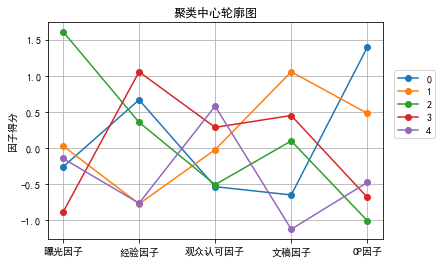

```python
# 将上述聚类中心DataFrame转置，注意列名和行名交换
ccT=pd.DataFrame(data=centers.T,columns=centers.index,index=centers.columns)

# 设置不显示负坐标轴，字体为黑体，绘制聚类中心轮廓图
plt.rcParams['axes.unicode_minus'] = False
plt.rcParams['font.sans-serif'] = ['simHei']
plt.plot(ccT,'o-')
plt.title('聚类中心轮廓图')
plt.ylabel('因子得分')
plt.legend(ccT.columns,bbox_to_anchor=(1.02, 0.8))
plt.grid(True)
```

根据因子得分，参照上述聚类中心轮廓图，将演员依次分类为“CP炒作类选手”，“文稿励志选手”，“高曝光度选手”，“经验丰富选手”，”平平无奇选手“。

```python
# 将聚类中心DataFrame行名(index)换为类别名
centers.index = ['CP炒作类选手', '文稿励志选手',  '高曝光度选手','经验丰富选手', '平平无奇选手']
# 展示聚类中心
centers
```

|  | 曝光因子 | 经验因子 | 观众认可因子 | 文稿因子 | CP因子 |
| --- | --- | --- | --- | --- | --- |
| CP炒作类选手 | -0.264412 | 0.667064 | -0.537512 | -0.652518 | 1.396736 |
| 文稿励志选手 | 0.029147 | -0.776363 | -0.024387 | 1.056029 | 0.479957 |
| 高曝光度选手 | 1.614457 | 0.356020 | -0.509770 | 0.096602 | -1.009967 |
| 经验丰富选手 | -0.893484 | 1.055326 | 0.285100 | 0.449458 | -0.685786 |
| 平平无奇选手 | -0.145397 | -0.766913 | 0.578645 | -1.127222 | -0.479095 |

# 任务五：分析演员热度

该任务中，我们将分析各个类别的脱口秀演员的热度情况。请在工作目录下找到"actor_hotness.csv"表格，这里我们有'微博粉丝数','中插代言数','视频播放量','搜索结果数'这四个变量，都能在一定程度上反应脱口秀演员的热度。为了能够得到最终反映演员热度的变量，我们使用了[熵权法](https://blog.csdn.net/weixin_45123009/article/details/113620235)，获得这四个指标对应权重，加权求和得到最终的"热度"指标来表示演员的综合热度。

```python
# 用pandas读取actor_hotness.csv表格
actor_hotness = pd.read_csv("actor_hotness.csv")
# 展示前5行
actor_hotness.head()
```

|  | 演员 | 中插代言数 | 微博粉丝数 | 搜索结果数 | 视频播放量 | 热度 | label |
| --- | --- | --- | --- | --- | --- | --- | --- |
| 0 | 庞博 | 3 | 256.0 | 16700000 | 48.367 | 0.763730 | 高曝光度选手 |
| 1 | 周奇墨 | 3 | 26.7 | 12000000 | 43.043 | 0.370773 | 高曝光度选手 |
| 2 | 何广智 | 4 | 49.2 | 5660000 | 61.083 | 0.453568 | 文稿励志选手 |
| 3 | 徐志胜 | 4 | 26.7 | 13000000 | 80.533 | 0.512475 | 文稿励志选手 |
| 4 | 呼兰 | 3 | 75.2 | 24100000 | 62.740 | 0.572736 | CP炒作类选手 |

```python
# 根据聚类类别聚合，计算得到每一类别的热度均值
grouped = actor_hotness['热度'].groupby(actor_hotness['label']).mean()

# 按照平均热度降序排列，展示各类别对应的平均热度
pd.DataFrame(grouped).sort_values(by=['热度'], ascending=False)
```

| label | 热度 |
| --- | --- |
| CP炒作类选手 | 0.465330 |
| 高曝光度选手 | 0.456322 |
| 文稿励志选手 | 0.294383 |
| 经验丰富选手 | 0.241783 |
| 平平无奇选手 | 0.184769 |

得到CP炒作选手和高爆光度选手的综合热度最高，文稿励志选手和经验丰富选手热度居中，平平无奇选手的综合热度最低。  
基于以上分析，可以给脱口秀演员提出几点建议：  
· 要么多制造话题，提高曝光度，要么找个选手组CP或者制造舆论  
· 依靠文本的积极性，给观众带来治愈也是有一定效果的  
· 最次也可以尝试“笨鸟先飞”，总有一天积累了足够的经验，热度也会上去  
· 不可以平平无奇，毫无特点，要给观众留下一定印象，才能有热度